# Zooplankton Annual Report

Arthur Barros, CDFW, arthur.barros@wildlife.ca.gov

2/2/2021

Data available on the Environmental Data Initiative portal at: https://portal.edirepository.org/nis/mapbrowse?packageid=edi.522.4  
Or the CDFW FTP site at: ftp://ftp.wildlife.ca.gov/IEP_Zooplankton/

## Introduction

Zooplankton are a vital trophic link between aquatic primary producers and higher-level consumers of the San Francisco Estuary (SFE). As primary consumers of phytoplankton, zooplankton facilitate the flow of carbon into a large and complex food web, historically supporting abundant fisheries in the region (Schroeter et al. 2015; Kimmerer et al. 2018). Many fishes, including Striped Bass (Morone saxatilis) and Chinook Salmon (Oncorhynchus tshawytscha) feed on zooplankton while rearing in the estuary as larvae and juveniles (Goertler et al. 2018; Heubach et al. 1963), while others like Tule Perch (Hysterocarpus traski) and Prickly Sculpin (Cottus asper) feed on zooplankton throughout their lifetimes (Kimmerer 2006Feyrer et al. 2003)). Zooplankton in the SFE are also a key food source for several endangered and threatened species, notably the Delta Smelt (Hypomesus transpacificus) and Longfin Smelt (Spirinchus thaleichthys) (Hobbs et al. 2006; Slater and Baxter 2014).

This importance of zooplankton prompted the implementation of the Zooplankton Study in 1972 to assess fish food resources in the upper SFE. Mandated by the State Water Resources Control Board’s Water Right Decision D-1641, the study is conducted jointly by the California Department of Fish and Wildlife and the California Department of Water Resources under the guidance and management of the Interagency Ecological Program. For nearly 5 decades, this study has monitored the zooplankton community in the region, tracking abundance trends and distributional patterns, detecting and monitoring introduced species, and documenting the dramatic shifts in the community’s composition. Changes in zooplankton abundance and composition have since been linked to major declines of the pelagic fishes in the upper estuary (Sommer et al. 2007; Winder and Jassby 2011). This report presents zooplankton annual and seasonal abundance indices and distribution trends from 1974 through 2019 for the most common copepods, cladocera, rotifers, and mysids of the upper estuary.

## Methods

Zooplankton sampling has been conducted since 1974 at least once a month March-November through 1995, monthly from 1995 on. at 20 fixed stations in the upper SFE (Figure 1). Three gear types are used for each sampling event: a pump with a 43-micron mesh net for micro-zooplankton (rotifers, nauplii, and small cyclopoid copepods); a Clarke-Bumpus (CB) net with a 160-micron mesh for sampling meso-zooplankton (cladocera and most juvenile and adult calanoid copepods); and a mysid net with a 505-micron mesh for sampling mysid shrimp and other macro-zooplankton. Both the mysid and CB nets are attached to a sled and towed obliquely from the bottom through the surface for a 10-minute tow. Volume is measured using a General Oceanics flowmeter placed in the mouth of each net so that: V=(end meter-start meter)k*a; where V is the volume of water sampled, k is a flowmeter correction value, and a is the area of the mouth of the net. The Teel Marine 12V utility pump is also used at each station to sample approximately 19.8 gallons from the entire water column, which is filtered through a 43-micron mesh net to concentrate the pump sample. Samples are preserved in 10% formalin with Rose Bengal dye before being processed in the laboratory for identification and enumeration of organisms using a dissecting microscope. More information about the sampling and processing methods can be found in the metadata at ftp://ftp.wildlife.ca.gov/IEP_Zooplankton/.

Abundance indices are calculated for each organism based on the gear type most effective at its capture and reported as the mean catch-per-unit-effort (CPUE). CPUE is calculated as the number of each organism collected per cubic meter of water sampled, so that: CPUE=s*V^(-1); where s is the estimated count of the target organism in the sample. Copepod abundance indices reported here only include adults, as juveniles were not always identified to species. Annual and seasonal abundance indices were calculated using 14 fixed stations sampled consistently since 1974 (Figure 1) and 2 non-fixed stations sampled where bottom specific conductance was roughly 2 and 6 millisiemens per centimeter (approximately 1 and 3 psu).

To analyze long-term trends (1974 to present), annual abundance indices were calculated as the mean CPUE for samples collected from March through November, as winter sampling was inconsistent before 1995. Seasonal abundance indices were calculated as the mean CPUE for samples collected during each season: winter (previous December to February), spring (March to May), summer (June to August), and fall (September to November). Long-term seasonal trends for winter are only shown for 1995 to present. Spatial distribution indices for organisms is described as seasonal mean CPUE for by region. Estuary regions were defined as San Pablo Bay (stations D41 and D41A), Suisun Bay (stations D6, 28, 54, and 48), Suisun Marsh (stations 32 and S42), West Delta (stations 60, 64, and 74), Central Delta (stations D16, 86, and D28), and the East Delta (92 and M10).

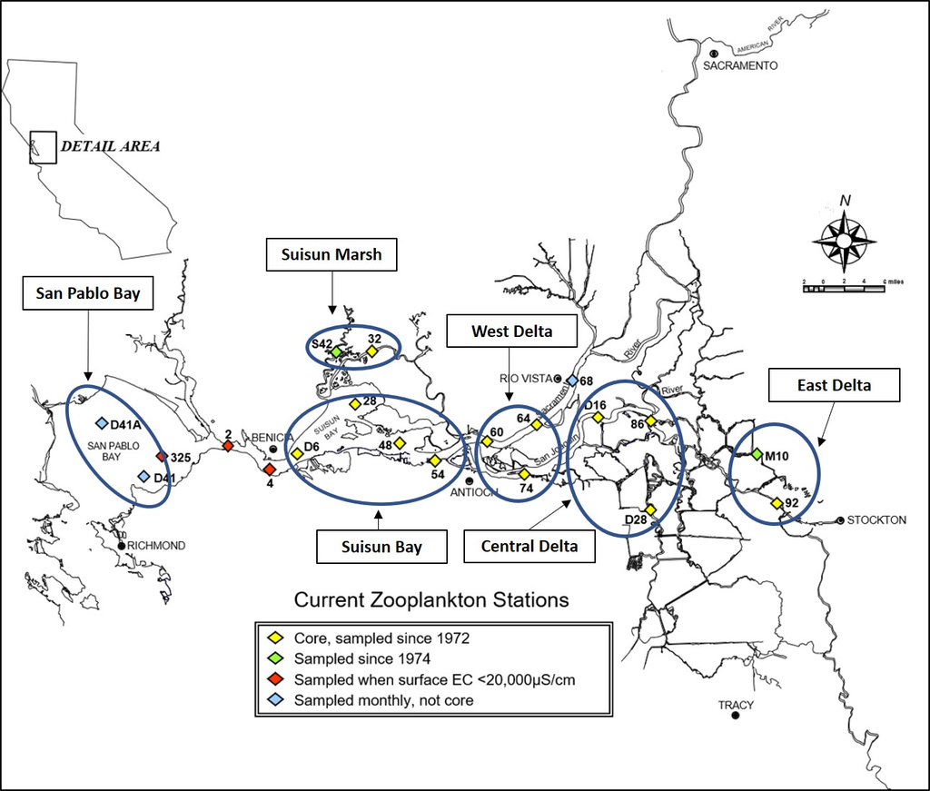

Figure 1: Map of fixed Zooplankton Study stations in the San Francisco Estuary.

## Trends

Since the implementation of the Zooplankton Study in 1974, a significant decrease in the overall abundance of zooplankton has been detected in the estuary (Figure 2). Only the abundance of cyclopoid copepods increased in the region during this period, driven by the invasion and spread of Limnoithona tetraspina. The overall decrease in zooplankton abundance in the estuary can be attributed to a series of invasions into the estuary, most notably that of the Asian clam Potamocorbula amurensis in the mid-1980s (Kimmerer, Gartside, and Orsi 1994; Carlton et al. 1990). The spread of P. amurensis throughout SFE has had significant impacts on planktonic abundance in the upper estuary due to its high filtration feeding rates on phytoplankton and copepod nauplii. Not only has abundance decreased for most of the zooplankton groups, but dramatic shifts in the composition of these communities have been detected during the study period. These changes have been driven by the introduction and spread of non-native zooplankton species throughout the estuary, compounded with changes to the abiotic and biotic environments.

#### Calanoid copepods

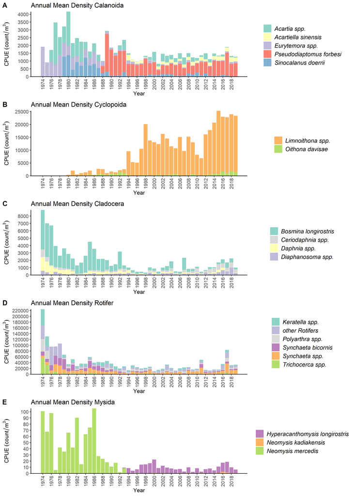

Figure 2: Annual (Mar-Nov) mean zooplankton CPUE for A) Calanoid CPUE in the CB net, B) Cyclopoida CPUE in pump samples, C) Cladocera CPUE in the CB net, D) Rotifer CPUE in pump samples, and E) Mysid CPUE in the mysid net.

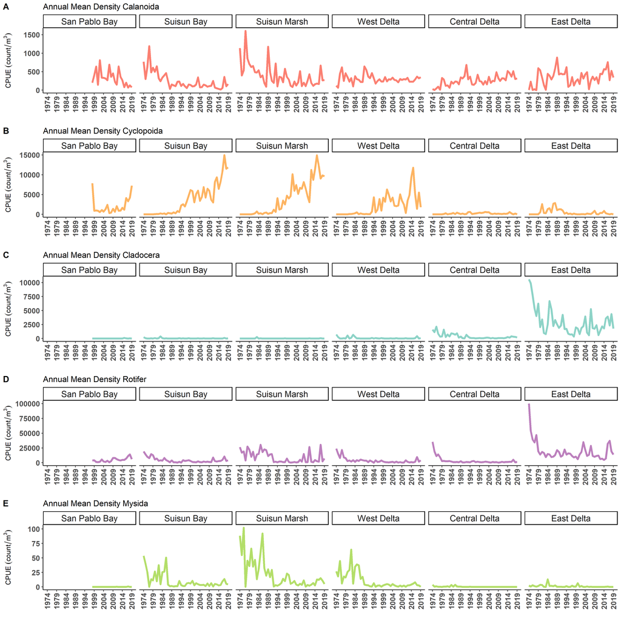

#### Cyclopoid copepods

Much smaller than calanoid copepods collected in the CB net, the Limnoithona cyclopoids are best retained in pump samples, which use a smaller mesh. Since the early 1990s, Limnoithona spp. abundance has been higher than calanoid copepod abundance, and the small L. tetraspina has become the most common copepod in the upper estuary. This increase in L. tetraspina abundance is likely due to a decline of Northern Anchovy in the upper SFE and subsequent decreased predation (Kimmerer 2006), as well as the cyclopoid’s small size, high growth rate, and motionless behavior, making it very difficult for visual feeders to capture (Bouley and Kimmerer 2006; Greene et al. 2011). These characteristics may increase its ability to escape predation in a region where visual predation is most dominant among fish (Kimmerer 2006). The introduction of L. tetraspina is also linked to the reduction of the range of P. forbesi out of the low-salinity zone of the estuary, as high L. tetraspina densities may have fed and sustained larger populations of the predatory A. sinensis, which also fed on P. forbesi nauplii (Kayfetz and Kimmerer 2017).

#### Cladocera

The cladoceran community of the upper estuary is composed of Bosmina, Daphnia, Ceriodaphnia, and Diaphanosoma species, whose populations have also substantially declined since the onset of the study (Figure 2C). These cladocera tend to be herbivorous, feeding primarily on phytoplankton, and were likely hard hit by the invasion of P. amurensis (Baxter et al. 2008; Kratina and Winder 2015). Cladocerans make up a significant portion in the diets of Delta Smelt, juvenile Chinook Salmon, and young-of-the-year Striped Bass throughout the upper estuary (Heubach et al. 1963; Slater and Baxter 2014; Goertler et al. 2018). The invasion and increase of available copepod prey such as P. forbesi and the decline in cladocera has created a shift in the nutritional content of the plankton community available for fish, with yet to be determined consequences (Kratina and Winder 2015).

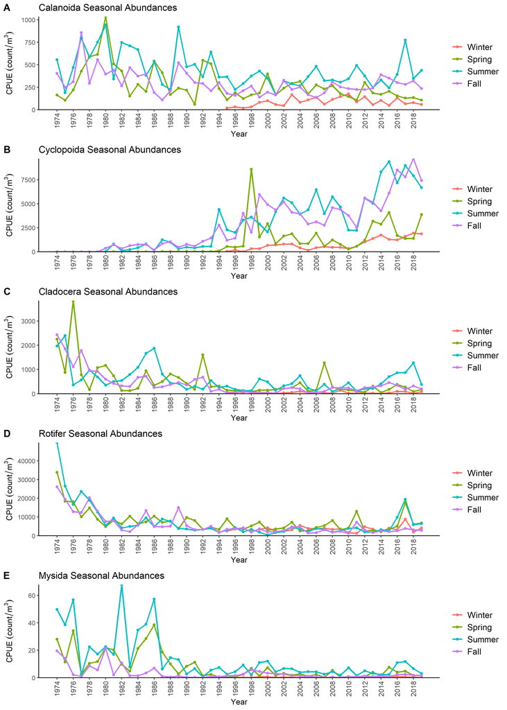

#### Rotifer

While they are the most abundant zooplankton in the estuary, long-term sampling of rotifers using the pump system shows a dramatic decrease in their annual abundance in the estuary since the beginning of this study (Figure 2D). Several species of rotifers make up the community: most abundant being the Polyarthra, Synchaeta, and Keratella genera. Interestingly, the decline of rotifer abundance beginning in the late 1970s preceded the invasion of P. amurensis in the estuary (Cloern and Jassby 2012).

#### Mysida

Not only have mysid abundances declined significantly since the 1970s, but the community has also shifted from being composed almost entirely by the native Neomysis mercedis, to being dominated by the non-native Hyperacanthomysis longirostris (formerly Acanthomysis bowmani) (Figure 2E). The first significant decline in N. mercedis occurred during the 1976-1977 drought, likely caused by food limitation from an absence of diatoms due to very low river discharges (Siegfried et al. 1979; Cloern et al. 1983). The populations of N. mercedis were able to rebound after the years of drought and stayed at high densities in the Suisun Bay region of the upper estuary until the introduction of P. amurensis in the mid-1980s, after which their numbers crashed.

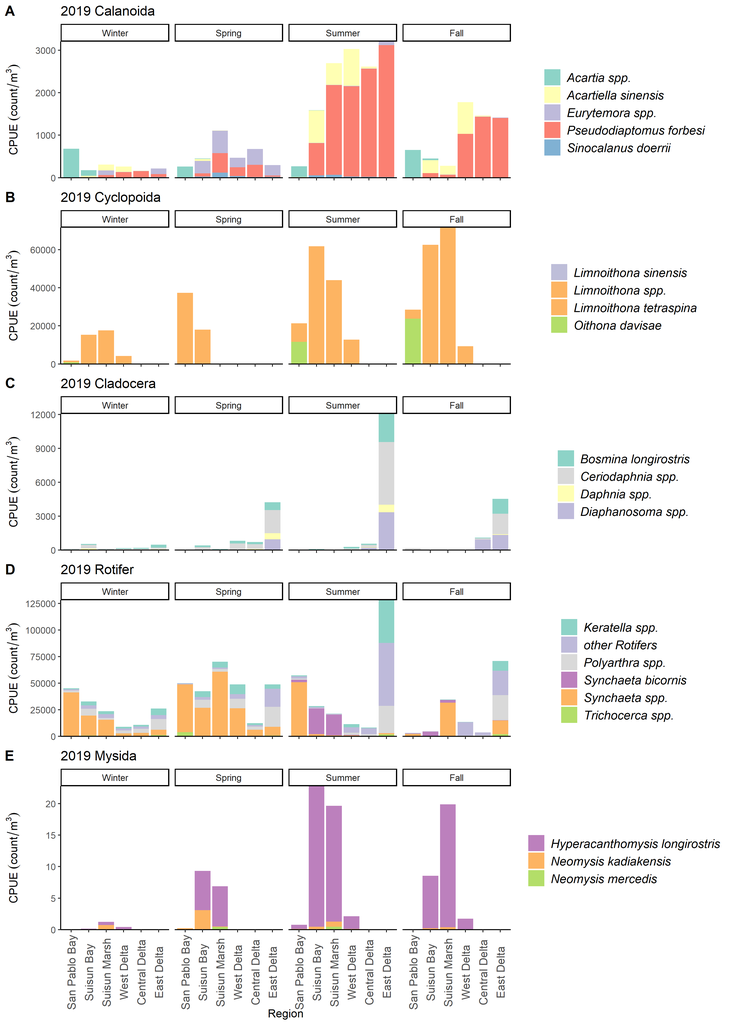

Figure 5: Seasonal mean zooplankton CPUE for reporting year by region for A) Calanoid CPUE in the CB net, B) Cyclopoida CPUE in pump samples, C) Cladocera CPUE in the CB net, D) Rotifer CPUE in pump samples, and E) Mysid CPUE in the mysid net.

## References

Baxter R, Feyrer F, Nobriga M, Sommer T. 2008. Pelagic Organism Decline Progress Report: 2007 Synthesis of Results. Bouley P, Kimmerer WJ. 2006. Ecology of a highly abundant, introduced cyclopoid copepod in a temperate estuary. Mar Ecol Prog Ser. 324(October):219–228.

Carlton JT, Thompson JK, Schemel LE, Nichols FH. 1990. Remarkable invasion of San Francisco Bay (California, USA) by the Asian clam Potamocorbula amurensis. I. Introduction and dispersal. Mar Ecol Prog Ser. 66:81–94.

CDFG. 2009. A Status Review of the Longfin Smelt (Spirinchus thaleichthys) in California. Sacramento.

Cloern JE, Alpine AE, Cole BE, Wong RLJ, Arthur JF, Ball MD. 1983. River discharge controls phytoplankton dynamics in the northern San Francisco Bay estuary. Estuar Coast Shelf Sci. 16(4):415–429.

Cloern JE, Jassby AD. 2012. Drivers of change in estuarine-coastal ecosystems: Discoveries from four decades of study in San Francisco Bay. Rev Geophys. 50:4001.

Ferrari FD, Orsi J. 1984. Oithona davisae, new species, and Limnoithona sinensis (Burckhardt, 1912) (Copepoda: Oithonidae) from the Sacramento-San Joaquin Estuary, California. J Crustac Biol. 4(1):106–126.

Feyrer F, Herbold B, Matern SA, Moyle PB. 2003. Dietary shifts in a stressed fish assemblage: Consequences of a bivalve invasion in the San Francisco Estuary.Goertler P, Jones K, Cordell J, Schreier B, Sommer T. 2018. Effects of extreme hydrologic regimes on juvenile Chinook Salmon prey resources and diet composition in a large river floodplain. Trans Am Fish Soc. 147:287–299.

Greene VE, Sullivan LJ, Thompson JK, Kimmerer WJ. 2011. Grazing impact of the invasive clam Corbula amurensis on the microplankton assemblage of the northern San Francisco estuary. Mar Ecol Prog Ser. 431(February):183–193.

Hennessy A. 2018. Zooplankton Monitoring 2017. Interag Ecol Progr Newsl. 32(1):21–32.

Heubach W, Toth RJ, Mccready AM. 1963. Food of Young-of-the-year Striped Bass (Roccus Saxatilis) in the Sacramento-San Joaquin River. Calif Fish Game. 49(4):224–239.

Hobbs JA, Bennett WA, Burton JE. 2006. Assessing nursery habitat quality for native smelts (Osmeridae) in the low-salinity zone of the San Francisco estuary. J Fish Biol. 69(3):907–922.

Kayfetz K, Kimmerer W. 2017. Abiotic and biotic controls on the copepod Pseudodiaptomus forbesi in the upper San Francisco Estuary. Mar Ecol Prog Ser. 581(Runge 1988):85–101.

Kimmerer W, Ignoffo TR, Bemowski B, Modéran J, Holmes A, Bergamaschi B. 2018. Zooplankton dynamics in the Cache Slough Complex of the upper San Francisco estuary. San Fr Estuary Watershed Sci. 16(3).

Kimmerer WJ. 2006. Response of anchovies dampens effects of the invasive bivalve Corbula amurensis on the San Francisco Estuary foodweb. Mar Ecol Prog Ser. 324(Cloern 1982):207–218.

Kimmerer WJ, Gartside E, Orsi JJ. 1994. Predation by an introduced clam as the likely cause of substantial declines in zooplankton of San Francisco Bay. Mar Ecol Prog Ser. 113(1–2):81–94.

Kratina P, Winder M. 2015. Biotic invasions can alter nutritional composition of zooplankton communities. Oikos. 124:1337–1345.

Modlin RF, Orsi JJ. 1997. Acanthomysis bowmani, a new species, and A. aspera Ii, Mysidacea newly reported from the Sacramento-San Joaquin Estuary, California (Crustacea: Mysidae). Proc Biol Soc Washingt. 110(3):439–446.

Moyle PB, Herbold B, Stevens DE, Miller LW. 1992. Life history and status of delta smelt in the Sacramento-San Joaquin estuary, California. Trans Am Fish Soc. 121(1):67–77.

Orsi J, Walter TC. 1991. Pseudodiaptomus forbesi and P. marinus (Copepoda: Calanoida), the latest copeopod immigrants to California’s Sacramento-San Joaquin Estuary. Bull Plankt Soc Japan.:553–562.

Orsi JJ, Bowman TE, Marelli DC, Hutchinson A. 1983. Recent introduction of the planktonic calanoid copepod Sinocalanus doerrii (Centropagidae) from mainland China to the Sacramento-San Joaquin Estuary of California. J Plankton Res. 5(3):357–375.

Orsi JJ, Ohtsuka S. 1999. Introduction of the Asian copepods Acartiella sinensis, Tortanus dextrilobatus (Copepoda: Calanoida), and Limnoithona tetraspina (Copepoda: Cyclopoida) to the San Francisco Estuary, California, USA. Plankt Biol Ecol. 46(2):128–131.

Schroeter RE, O’Rear TA, Young MJ, Moyle PB. 2015. The aquatic trophic ecology of Suisun Marsh, San Francisco Estuary, California, during autumn in a wet year. San Fr Estuary Watershed Sci. 13(3).

Siegfried CA, Kopache ME, Knight AW. 1979. The Distribution and Abundance of Neomysis mercedis in Relation to the Entrapment Zone in the Western Sacramento-San Joaquin Delta. Trans Am Fish Soc. 108(3):262–270.

Slater SB, Baxter R. 2014. Diet, Prey Selection, and Body Condition of Age-0 Delta Smelt, Hypomesus transpacificus, in the Upper San Francisco Estuary. San Fr Estuary Watershed Sci. 12(3):1–24.

Sommer T, Armor C, Baxter R, Breuer R, Brown L, Chotkowski M, Culberson S, Feyerer F, Gingras M, Herbold B, et al. 2007. The collapse of pelagic fishes in the upper San Francisco Estuary. Fisheries. 32(6):270–277.

Winder M, Jassby AD. 2011. Shifts in Zooplankton Community Structure: Implications for Food Web Processes in the Upper San Francisco Estuary. Estuaries and Coasts. 34:675–690.